# New York City elevators

Bernadett Piros

2023-03-07

This is an analysis of New York City elevators. The data comes from TidyTuesday (2022-12-06). This data contains a set of the registered elevator devices in New York City.

The goal of this analysis is to get answer to questions that what kind of elevator devices are in NYC and what their distribution is, what is the relationship between elevator capacity, speed per device type and who are the most popular elevator manufacturers.

Although, the original data was provided by a local government agency, namely by the NYC Department of Buildings, it contains a couple of errors and a lot of missing details - particularly in the technical details.

# What kind of elevator devices are in New York and what their distribution is?

New York City, home of skycrapers, had more than 76000 elevators in 2015, most of them active. Each day these elevators move millions of people up and down and lift huge amount of cargo and items in every size.

Almost 5% of elevators belong to the New York City Housing Authority, which provides public housing and which is the largest public housing authority in North America.

Nearly 2% of the elevators were dismantled. Dismantling allows for future restoration of an elevator but no longer requires annual permits or inspections.

Distribution per status

| Status | Number | Percent |
| --- | --- | --- |
| ACTIVE | 66885 | 87.90 |
| NYCHA | 3365 | 4.42 |
| WK IN PROG | 2349 | 3.09 |
| NO JURIST | 1983 | 2.61 |
| DISMANTLED | 1506 | 1.98 |

Distribution per borough

| Borough | Number | Percent |
| --- | --- | --- |
| Manhattan | 43596 | 57.32 |
| Brooklyn | 13980 | 18.38 |
| Queens | 9683 | 12.73 |
| Bronx | 7575 | 9.96 |
| Staten Island | 1227 | 1.61 |

Most of the elevator devices are passenger elevators. The second largest group is freight, the third largest one is the escalator while the number of other types are smaller.

Distribution per device type

| Device type | Number | Percent |
| --- | --- | --- |
| Passenger Elevator (P) | 66602 | 87.53 |
| Freight (F) | 4140 | 5.44 |
| Escalator (E) | 2663 | 3.50 |
| Dumbwaiter (D) | 1143 | 1.50 |
| Sidewalk (S) | 943 | 1.24 |
| Private Elevator (T) | 252 | 0.33 |
| Handicap Lift (H) | 227 | 0.30 |
| Manlift (M) | 73 | 0.10 |
| Public Elevator (L) | 45 | 0.06 |

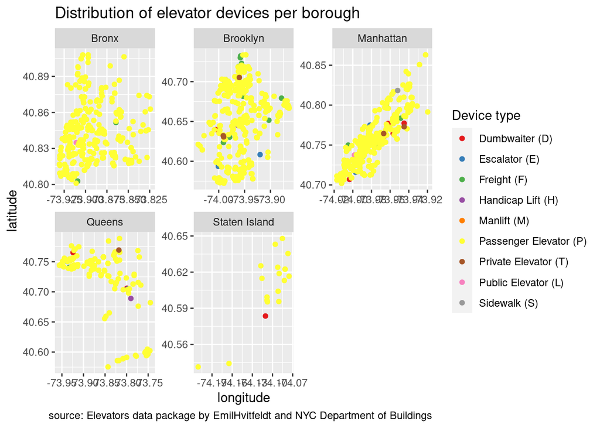

## Who are the most popular elevator manufacturers in NYC?

The very first commercial elevator in New York City was manufactured by OTIS and installed in the Haughwout building in 1857. Since that time OTIS shows a steady popularity. We can say that HOUSING AUTHORITY, PRIVATE RESIDENCE, MRL ELEVATOR and STALEY belong to the more-than-1000-elevator club besides OTIS.

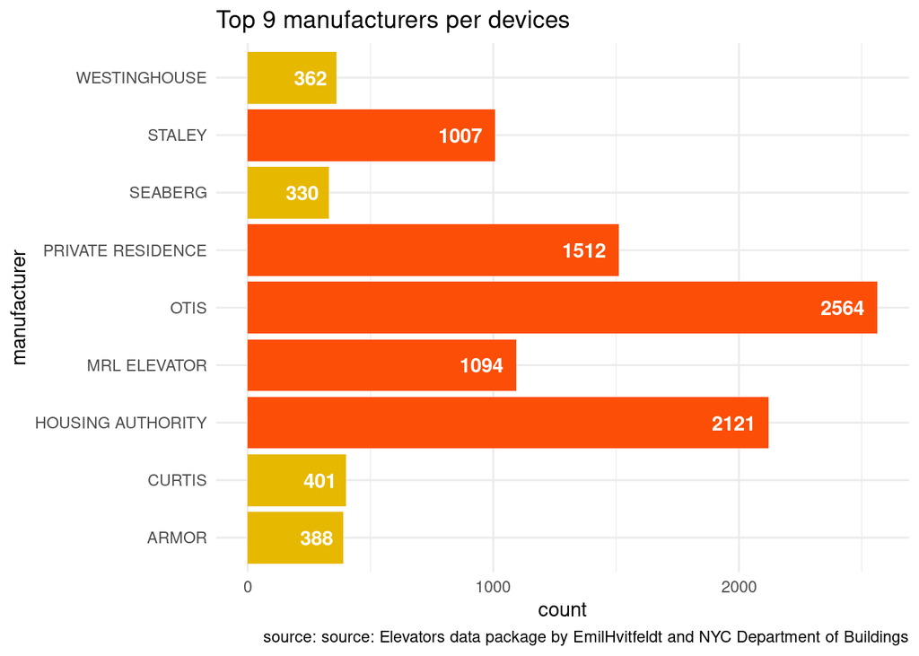

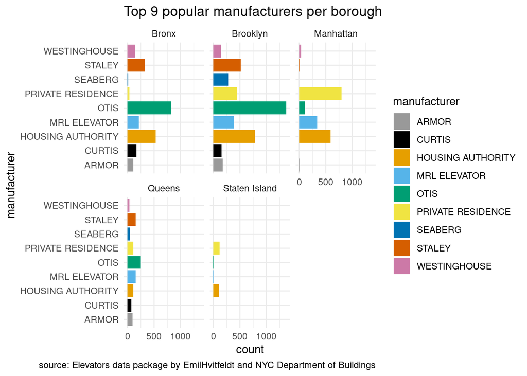

### What is the relationship between elevator capacity, per and device type?

As it was expected, escalators and freight elevators have the biggest capacity. These devices are originally designed to lift enormous loads.

Note: Some capacity data must be incorrect in this data set because based on Google search the Barclays Center in Brooklyn tends to have the biggest capacity elevator of 80000 lbs.

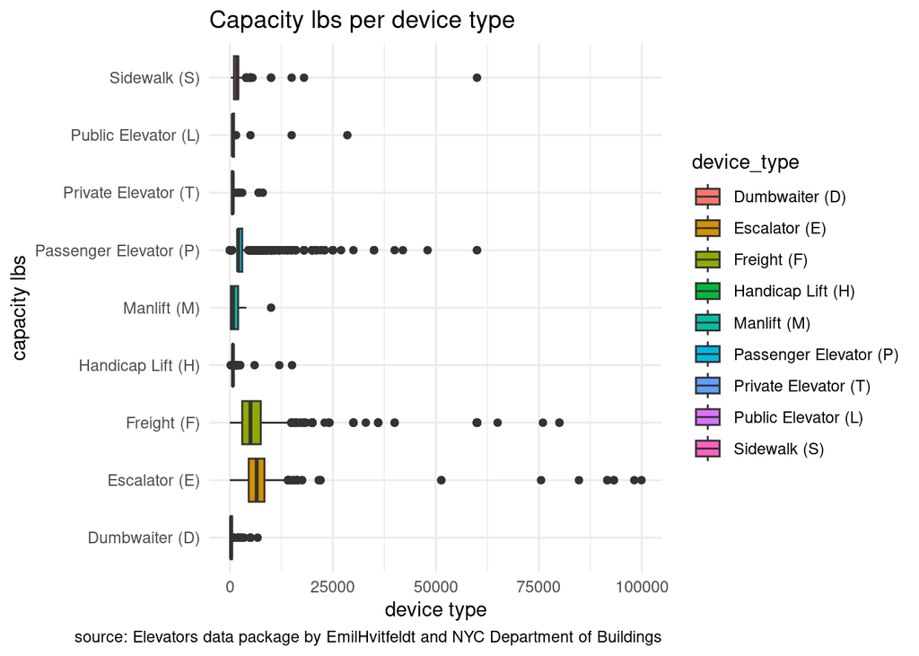

With regards to speed, passenger elevators cannot be beat. To lessen the time residents have to spend in elevators, more and more residental towers are being equipped with high-speed elevators.

Note: There are some definitely incorrect speed data in this data set because based on Google search the fastest elevator in New York City is located in the One World Trade Center and travels at an average speed of 23 mph (~ 2024 fpm).

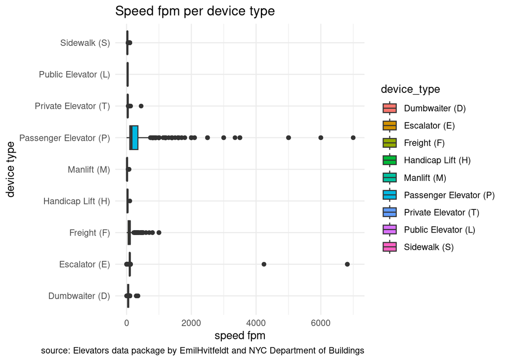

If both capacity and speed are considered at the same time, OTIS tends to win the first place.

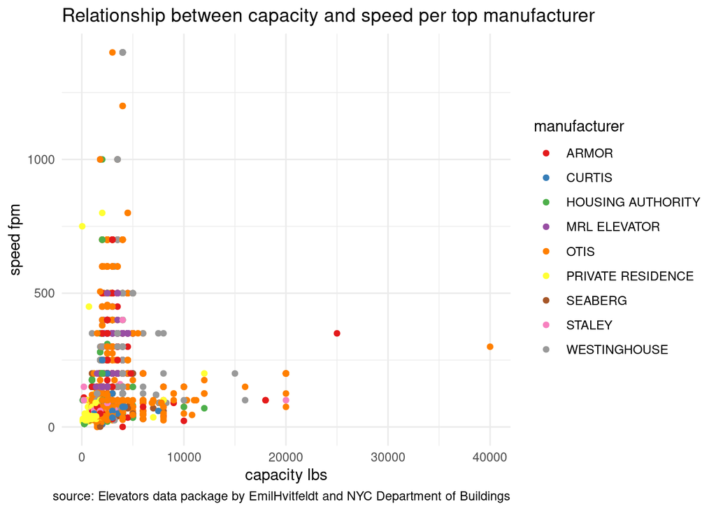

Elevators are a part of everyday life, without them, the skyline of New York City would look entirely different. They have significant impact on industry, housing and economy. If they break down, or there are disruptions, whether in a luxury building or at an industrial complex, it is cruical to get them amended or replaced as soon as possible. This is why it is so important to have an up-to-date data that can be analysed to draw conclusions that can help to support all elevator maintenance challenges.

#### Appendix

Zoom to the map to find where the active freight elevator devices above 40000 lbs capacity with known manufacturer are located.

[interactive chart not shown]

Zoom to the map to find where the active passenger elevator devices above 2000 fmp speed with known manufacturer are located.

[interactive chart not shown]

Zoom to the map to find where the dismantled elevator devices with known manufacturer are located.

[interactive chart not shown]

Citations

```
##
##
##   R Core Team (2022). R: A language and environment for statistical
##   computing. R Foundation for Statistical Computing, Vienna, Austria.
##   URL https://www.R-project.org/.
##
## A BibTeX entry for LaTeX users is
##
##   @Manual{,
##     title = {R: A Language and Environment for Statistical Computing},
##     author = {{R Core Team}},
##     organization = {R Foundation for Statistical Computing},
##     address = {Vienna, Austria},
##     year = {2022},
##     url = {https://www.R-project.org/},
##   }
##
## We have invested a lot of time and effort in creating R, please cite it
## when using it for data analysis. See also 'citation("pkgname")' for
## citing R packages.
```

```
##
##
##   Hughes E (2022). _tidytuesdayR: Access the Weekly 'TidyTuesday'
##   Project Dataset_. R package version 1.0.2,
##   <https://CRAN.R-project.org/package=tidytuesdayR>.
##
## A BibTeX entry for LaTeX users is
##
##   @Manual{,
##     title = {tidytuesdayR: Access the Weekly 'TidyTuesday' Project Dataset},
##     author = {Ellis Hughes},
##     year = {2022},
##     note = {R package version 1.0.2},
##     url = {https://CRAN.R-project.org/package=tidytuesdayR},
##   }
```

```
##
##
##   Wickham H, Averick M, Bryan J, Chang W, McGowan LD, François R,
##   Grolemund G, Hayes A, Henry L, Hester J, Kuhn M, Pedersen TL, Miller
##   E, Bache SM, Müller K, Ooms J, Robinson D, Seidel DP, Spinu V,
##   Takahashi K, Vaughan D, Wilke C, Woo K, Yutani H (2019). "Welcome to
##   the tidyverse." _Journal of Open Source Software_, *4*(43), 1686.
##   doi:10.21105/joss.01686 <https://doi.org/10.21105/joss.01686>.
##
## A BibTeX entry for LaTeX users is
##
##   @Article{,
##     title = {Welcome to the {tidyverse}},
##     author = {Hadley Wickham and Mara Averick and Jennifer Bryan and Winston Chang and Lucy D'Agostino McGowan and Romain François and Garrett Grolemund and Alex Hayes and Lionel Henry and Jim Hester and Max Kuhn and Thomas Lin Pedersen and Evan Miller and Stephan Milton Bache and Kirill Müller a…
##     year = {2019},
##     journal = {Journal of Open Source Software},
##     volume = {4},
##     number = {43},
##     pages = {1686},
##     doi = {10.21105/joss.01686},
##   }
```

```
##
##
##   Firke S (2023). _janitor: Simple Tools for Examining and Cleaning
##   Dirty Data_. R package version 2.2.0,
##   <https://CRAN.R-project.org/package=janitor>.
##
## A BibTeX entry for LaTeX users is
##
##   @Manual{,
##     title = {janitor: Simple Tools for Examining and Cleaning Dirty Data},
##     author = {Sam Firke},
##     year = {2023},
##     note = {R package version 2.2.0},
##     url = {https://CRAN.R-project.org/package=janitor},
##   }
```

```
##
##
##   Garrett Grolemund, Hadley Wickham (2011). Dates and Times Made Easy
##   with lubridate. Journal of Statistical Software, 40(3), 1-25. URL
##   https://www.jstatsoft.org/v40/i03/.
##
## A BibTeX entry for LaTeX users is
##
##   @Article{,
##     title = {Dates and Times Made Easy with {lubridate}},
##     author = {Garrett Grolemund and Hadley Wickham},
##     journal = {Journal of Statistical Software},
##     year = {2011},
##     volume = {40},
##     number = {3},
##     pages = {1--25},
##     url = {https://www.jstatsoft.org/v40/i03/},
##   }
```

```
##
##
##   H. Wickham. ggplot2: Elegant Graphics for Data Analysis.
##   Springer-Verlag New York, 2016.
##
## A BibTeX entry for LaTeX users is
##
##   @Book{,
##     author = {Hadley Wickham},
##     title = {ggplot2: Elegant Graphics for Data Analysis},
##     publisher = {Springer-Verlag New York},
##     year = {2016},
##     isbn = {978-3-319-24277-4},
##     url = {https://ggplot2.tidyverse.org},
##   }
```

```
##
##
##   Arnold J (2021). _ggthemes: Extra Themes, Scales and Geoms for
##   'ggplot2'_. R package version 4.2.4,
##   <https://CRAN.R-project.org/package=ggthemes>.
##
## A BibTeX entry for LaTeX users is
##
##   @Manual{,
##     title = {ggthemes: Extra Themes, Scales and Geoms for 'ggplot2'},
##     author = {Jeffrey B. Arnold},
##     year = {2021},
##     note = {R package version 4.2.4},
##     url = {https://CRAN.R-project.org/package=ggthemes},
##   }
```

```
##
##
##   Cheng J, Karambelkar B, Xie Y (2022). _leaflet: Create Interactive
##   Web Maps with the JavaScript 'Leaflet' Library_. R package version
##   2.1.1, <https://CRAN.R-project.org/package=leaflet>.
##
## A BibTeX entry for LaTeX users is
##
##   @Manual{,
##     title = {leaflet: Create Interactive Web Maps with the JavaScript 'Leaflet'
## Library},
##     author = {Joe Cheng and Bhaskar Karambelkar and Yihui Xie},
##     year = {2022},
##     note = {R package version 2.1.1},
##     url = {https://CRAN.R-project.org/package=leaflet},
##   }
```